# TreeClassification-HighRes-IndividualUser

Aitor Apaolaza

12/01/2016

*Copyright (c) 2015 The University of Manchester, UK.*

*Licenced under LGPL version 2.1. See LICENCE for details.*

*The IDInteraction Attention Classification was developed in the IDInteraction project, funded by the Engineering and Physical Sciences Research Council, UK through grant agreement number EP/M017133/1.*

*Author: Aitor Apaolaza*

## Initialisation and loading data

```
## [1] "All listed packages are already installed"
```

# Setup for the classification algorithm.

**Folder**: /home/aitor/Dropbox/UoM/IDInteractionCode/Rnotebooks

**Experiment**: dual_screen_free_experiment

**Source Videos**: high_quality

**Tracking system**: front_eyes_only

**Using the following list of participants**: P09.

**Using the following timelimit threshold to separate training and testing data**: 5.

Data for these participants will be read from the CSV files contained in the following folders:

/home/aitor/Dropbox/UoM/IDInteractionCode/Rnotebooks/resources/dual_screen_free_experiment/high_quality/attention/

/home/aitor/Dropbox/UoM/IDInteractionCode/Rnotebooks/resources/dual_screen_free_experiment/high_quality/front_eyes_only/

Loading data for participant P09

```
## [1] "Processing participant: P09"
## [1] "START of combineCSVsToDF()"
## [1] "END of combineCSVsToDF()"
## [1] "START of createFeatureDF()"
## [1] "END of createFeatureDF()"
```

## Training the tree classifier

Using the **rpart** library for the following formula:

**attentionName ~ boxHeight + boxRotation + boxArea + boxWidth + widthHeightRatio + boxYcoordRel**

Resulting model:

```
## n= 14642
##
## node), split, n, loss, yval, (yprob)
##       * denotes terminal node
##
##   1) root 14642 4963 tv (0.33895643 0.66104357)
##     2) boxYcoordRel>=0.582608 3974  544 ipad (0.86311022 0.13688978)
##       4) boxHeight< 12.78365 2124   50 ipad (0.97645951 0.02354049) *
##       5) boxHeight>=12.78365 1850  494 ipad (0.73297297 0.26702703)
##        10) boxRotation>=-4.42406 1134  115 ipad (0.89858907 0.10141093)
##          20) boxRotation< 7.641665 1058   48 ipad (0.95463138 0.04536862) *
##          21) boxRotation>=7.641665 76    9 tv (0.11842105 0.88157895) *
##        11) boxRotation< -4.42406 716  337 tv (0.47067039 0.52932961)
##          22) boxHeight< 13.20445 361   92 ipad (0.74515235 0.25484765)
##            44) boxYcoordRel>=0.5928223 246    8 ipad (0.96747967 0.03252033) *
##            45) boxYcoordRel< 0.5928223 115   31 tv (0.26956522 0.73043478) *
##          23) boxHeight>=13.20445 355   68 tv (0.19154930 0.80845070) *
##     3) boxYcoordRel< 0.582608 10668 1533 tv (0.14370079 0.85629921)
##       6) boxHeight>=46.0635 362   93 ipad (0.74309392 0.25690608)
##        12) boxYcoordRel>=0.5075439 300   31 ipad (0.89666667 0.10333333) *
##        13) boxYcoordRel< 0.5075439 62    0 tv (0.00000000 1.00000000) *
##       7) boxHeight< 46.0635 10306 1264 tv (0.12264700 0.87735300)
##        14) boxYcoordRel>=0.5164711 5925 1140 tv (0.19240506 0.80759494)
##          28) boxHeight>=21.9007 2283  832 tv (0.36443276 0.63556724)
##            56) boxHeight< 43.25825 395   48 ipad (0.87848101 0.12151899) *
##            57) boxHeight>=43.25825 1888  485 tv (0.25688559 0.74311441)
##             114) boxHeight>=44.7565 210   38 ipad (0.81904762 0.18095238) *
##             115) boxHeight< 44.7565 1678  313 tv (0.18653159 0.81346841) *
##          29) boxHeight< 21.9007 3642  308 tv (0.08456892 0.91543108) *
##        15) boxYcoordRel< 0.5164711 4381  124 tv (0.02830404 0.97169596) *
```

From the R manual for the Complexity Parameter Table for an Rpart Fit: *The cptable in the fit contains the mean and standard deviation of the errors in the cross-validated prediction against each of the geometric means.*

Matrix of information on the optimal prunings based on a complexity parameter.

```
##
## Classification tree:
## rpart(formula = formula, data = trainsetclass, method = "class")
##
## Variables actually used in tree construction:
## [1] boxHeight    boxRotation  boxYcoordRel
##
## Root node error: 4963/14642 = 0.33896
##
## n= 14642
##
##         CP nsplit rel error  xerror      xstd
## 1 0.581503      0   1.00000 1.00000 0.0115410
## 2 0.035462      1   0.41850 0.42011 0.0085202
## 3 0.020082      2   0.38303 0.38706 0.0082315
## 4 0.014709      6   0.29579 0.30324 0.0074041
## 5 0.012492      9   0.25166 0.25992 0.0069107
## 6 0.011686     10   0.23917 0.25146 0.0068080
## 7 0.010679     11   0.22748 0.24320 0.0067055
## 8 0.010000     12   0.21680 0.22446 0.0064642
```

Visualisation of the Complexity Parameter Table. *A good choice of cp for pruning is often the leftmost value for which the mean lies below the horizontal line.*

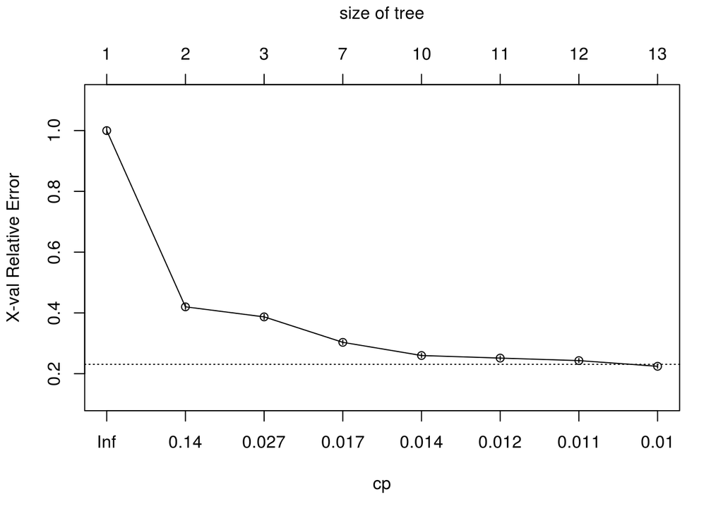

## Tree

### Summary of the tree

```
##
## Model formula:
## attentionName ~ boxHeight + boxRotation + boxArea + boxWidth +
##     widthHeightRatio + boxYcoordRel
##
## Fitted party:
## [1] root
## |   [2] boxYcoordRel >= 0.58261
## |   |   [3] boxHeight < 12.78365: ipad (n = 2124, err = 2.4%)
## |   |   [4] boxHeight >= 12.78365
## |   |   |   [5] boxRotation >= -4.42406
## |   |   |   |   [6] boxRotation < 7.64166: ipad (n = 1058, err = 4.5%)
## |   |   |   |   [7] boxRotation >= 7.64166: tv (n = 76, err = 11.8%)
## |   |   |   [8] boxRotation < -4.42406
## |   |   |   |   [9] boxHeight < 13.20445
## |   |   |   |   |   [10] boxYcoordRel >= 0.59282: ipad (n = 246, err = 3.3%)
## |   |   |   |   |   [11] boxYcoordRel < 0.59282: tv (n = 115, err = 27.0%)
## |   |   |   |   [12] boxHeight >= 13.20445: tv (n = 355, err = 19.2%)
## |   [13] boxYcoordRel < 0.58261
## |   |   [14] boxHeight >= 46.0635
## |   |   |   [15] boxYcoordRel >= 0.50754: ipad (n = 300, err = 10.3%)
## |   |   |   [16] boxYcoordRel < 0.50754: tv (n = 62, err = 0.0%)
## |   |   [17] boxHeight < 46.0635
## |   |   |   [18] boxYcoordRel >= 0.51647
## |   |   |   |   [19] boxHeight >= 21.9007
## |   |   |   |   |   [20] boxHeight < 43.25825: ipad (n = 395, err = 12.2%)
## |   |   |   |   |   [21] boxHeight >= 43.25825
## |   |   |   |   |   |   [22] boxHeight >= 44.7565: ipad (n = 210, err = 18.1%)
## |   |   |   |   |   |   [23] boxHeight < 44.7565: tv (n = 1678, err = 18.7%)
## |   |   |   |   [24] boxHeight < 21.9007: tv (n = 3642, err = 8.5%)
## |   |   |   [25] boxYcoordRel < 0.51647: tv (n = 4381, err = 2.8%)
##
## Number of inner nodes:    12
## Number of terminal nodes: 13
```

### Visualisation of the tree

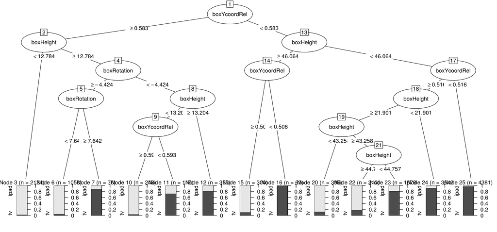

Tree classifier plot

## Error metrics analysis

Confusion matrix from the application of the tree predictor to the testing set of data.

```
##       predclass
##         ipad    tv
##   ipad  7860  3530
##   tv   11531  7724
```

### Error metrics based on prediction of attention to the iPad.

True negatives: 7724

False negatives: 11531

True positives: 7860

False positives: 3530

**Error-rate**: the proportion of the incorrectly classified examples -> (fp+fn)/(tp+tn+fp+tn)

**49.1466797**

**Accuracy**: the proportion of the correctly classified examples -> (tp+tn)/(tp+tn+fp+tn)

**50.8533203**

**Precision**: positive predicted value (PPV) -> tp/(tp+fp), a measure of exactness

**69.0079017**

**Recall/Sensitivity**: true positive recognition rate -> tp/(tp+fn), a measure of completeness

**40.5342685**

**Specificity**: true negative recognition rate -> tn/(tn+fp)

**68.6333748**

**F measure**: the balance between precision and recall -> 2*tp/(2*tp+fp+fn)

**51.0704655**

# ERROR MEASURES INLINE COPY

P09 **49.1466797** **50.8533203** **69.0079017** **40.5342685** **68.6333748** **51.0704655**

### Error metrics based on prediction of attention to the TV.

True negatives: 7860

False negatives: 3530

True positives: 7724

False positives: 11531

**Error-rate**: the proportion of the incorrectly classified examples -> (fp+fn)/(tp+tn+fp+tn)

**49.1466797**

**Accuracy**: the proportion of the correctly classified examples -> (tp+tn)/(tp+tn+fp+tn)

**50.8533203**

As the number of instances of the response variable is not balanced (there are many more instances with false than true) the accuracy is not a good indicator. Other cost sensitive measures are reported here. -> cost sensitive measures

**Precision**: positive predicted value (PPV) -> tp/(tp+fp), a measure of exactness

**40.114256**

**Recall/Sensitivity**: true positive recognition rate -> tp/(tp+fn), a measure of completeness

**68.6333748**

**Specificity**: true negative recognition rate -> tn/(tn+fp)

**40.5342685**

**F measure**: the balance between precision and recall -> 2*tp/(2*tp+fp+fn)

**50.6342391**